# Interpreting Linear Regressions

The interpretation of coefficients in (generalized) linear models is more subtle than you many realise, and has consequences for how we test hypotheses and report findings. We will start by talking about **marginal vs. conditional interpretations** of model parameters.

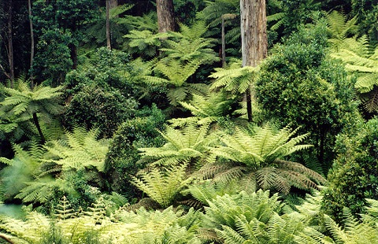

In this example, we model plant height as a function of altitude and temperature. These variables are negatively correlated: it is colder the higher you go. We start by simulating some data to reflect this.

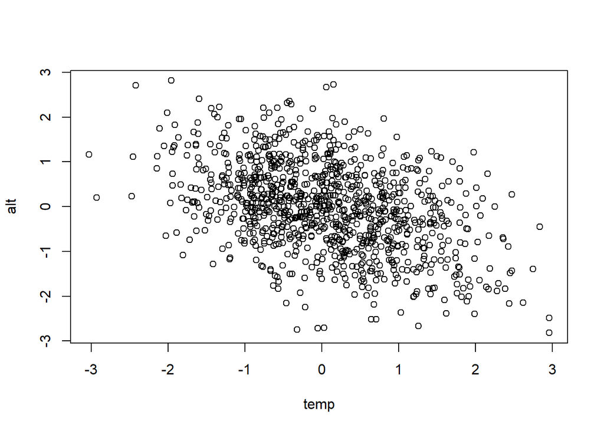

```r
library(mvtnorm)

# Specify the sample size
N <- 1000

# Specify the correlation between altitude and temperature
rho <- -0.4

# This line of code creates two correlated variables
X <- rmvnorm(N, mean = c(0, 0), sigma = matrix(c(1, rho, rho, 1), 2, 2))

# Extract the first and second columns to vectors named temp and alt and plot
temp <- X[, 1]
alt <- X[, 2]
plot(temp, alt)
```

Now we can simulate some data for height of plants. Here we say that the mean height of plants is 2 (when all the other variables are 0), as temperature increases by one unit (holding altitude constant), the mean of height will increase by 1 unit (`beta[2] = 1`), and similarly as you increase altitude by 1 unit (holding temperature constant) then mean height decreases by 1 (`beta[3] = -1`). Height is then normally distributed with this mean and standard deviation of 2.

```r
beta <- c(2, 1, -1)
mu <- beta[1] + beta[2] * temp + beta[3] * alt
height <- rnorm(N, mu, sd = 2)
```

If we use a linear model to find the coefficients we get what we expect, estimates very close to the true values.

```r
lm_both <- lm(height ~ temp + alt)
data.frame(estimated = round(lm_both$coefficients, 2), true = beta)
```

```
##             estimated true
## (Intercept)      1.90    2
## temp             1.00    1
## alt             -1.07   -1
```

The intercept is the predicted value when all the other variables are set to 0, which sometimes makes sense (here it would be the height of plants at sea level and 0 temperature). Other times 0 is not a meaningful value, and if you would like to interpret the intercept it might make sense to rescale your other variables so that their mean is 0. If you do this, then the intercept is the predicted value when all other variables are at their mean level.

What if now we had a model with just temperature?

```r
lm1 <- lm(height ~ temp)
lm1$coefficients
```

```
## (Intercept)        temp
##    1.885506    1.452772
```

Note: When statisticians talk about this, they use the words **conditional** and **marginal**. Conditional is the effect of a variable when others are held constant (as in lm_both), while marginal is the overall effect (as in lm1). Note: If you use the code above to simulate your own data sets, you will get slightly different values for the coefficients.

### Testing hypotheses

This distinction has a lot of consequences for modelling as well as testing hypothesis. Let’s generate some data where altitude predicts height, and temperature has no (additional) information, and then test for temperature.

```r
mu <- 2 - 1 * alt
height <- rnorm(N, mu, sd = 2)

mod_temp <- lm(height ~ temp)
summary(mod_temp)
```

```
##
## Call:
## lm(formula = height ~ temp)
##
## Residuals:
##     Min      1Q  Median      3Q     Max
## -7.2156 -1.4241 -0.0324  1.3905  7.7793
##
## Coefficients:
##             Estimate Std. Error t value Pr(>|t|)
## (Intercept)  2.07763    0.06809  30.515  < 2e-16 ***
## temp         0.33292    0.06915   4.815  1.7e-06 ***
## ---
## Signif. codes:  0 '***' 0.001 '**' 0.01 '*' 0.05 '.' 0.1 ' ' 1
##
## Residual standard error: 2.15 on 998 degrees of freedom
## Multiple R-squared:  0.0227, Adjusted R-squared:  0.02172
## F-statistic: 23.18 on 1 and 998 DF,  p-value: 1.703e-06
```

```r
anova(mod_temp)
```

```
## Analysis of Variance Table
##
## Response: height
##            Df Sum Sq Mean Sq F value    Pr(>F)
## temp        1  107.2 107.151  23.181 1.703e-06 ***
## Residuals 998 4613.1   4.622
## ---
## Signif. codes:  0 '***' 0.001 '**' 0.01 '*' 0.05 '.' 0.1 ' ' 1
```

But what about altitude? We know the temperature effect we observe is because it is correlated with altitude, temperature does not directly predict height. If we want to know if there is an effect of temperature after controlling for altitude (holding altitude constant, so conditional), then we fit the model with altitude and then test for temperature.

```r
mod_temp_alt <- lm(height ~ alt + temp)
summary(mod_temp_alt)
```

```
##
## Call:
## lm(formula = height ~ alt + temp)
##
## Residuals:
##     Min      1Q  Median      3Q     Max
## -6.5762 -1.3132 -0.0008  1.2739  6.8750
##
## Coefficients:
##             Estimate Std. Error t value Pr(>|t|)
## (Intercept)  2.08709    0.06218  33.563   <2e-16 ***
## alt         -0.98957    0.07005 -14.126   <2e-16 ***
## temp        -0.08081    0.06961  -1.161    0.246
## ---
## Signif. codes:  0 '***' 0.001 '**' 0.01 '*' 0.05 '.' 0.1 ' ' 1
##
## Residual standard error: 1.964 on 997 degrees of freedom
## Multiple R-squared:  0.1857, Adjusted R-squared:  0.1841
## F-statistic: 113.7 on 2 and 997 DF,  p-value: < 2.2e-16
```

```r
anova(mod_temp_alt)
```

```
## Analysis of Variance Table
##
## Response: height
##            Df Sum Sq Mean Sq  F value Pr(>F)
## alt         1  871.3  871.31 226.0005 <2e-16 ***
## temp        1    5.2    5.20   1.3476  0.246
## Residuals 997 3843.8    3.86
## ---
## Signif. codes:  0 '***' 0.001 '**' 0.01 '*' 0.05 '.' 0.1 ' ' 1
```

Note: The distinction between conditional and marginal interpretations is also true for generalised linear models and mixed models.

### Categorical covariates

When we have categorical covariates (for example treatment), there are a number of ways to code the model, which will give different interpretations for the coefficients. Let’s simulate 120 data points with 40 in each of three levels of a categorical treatment.

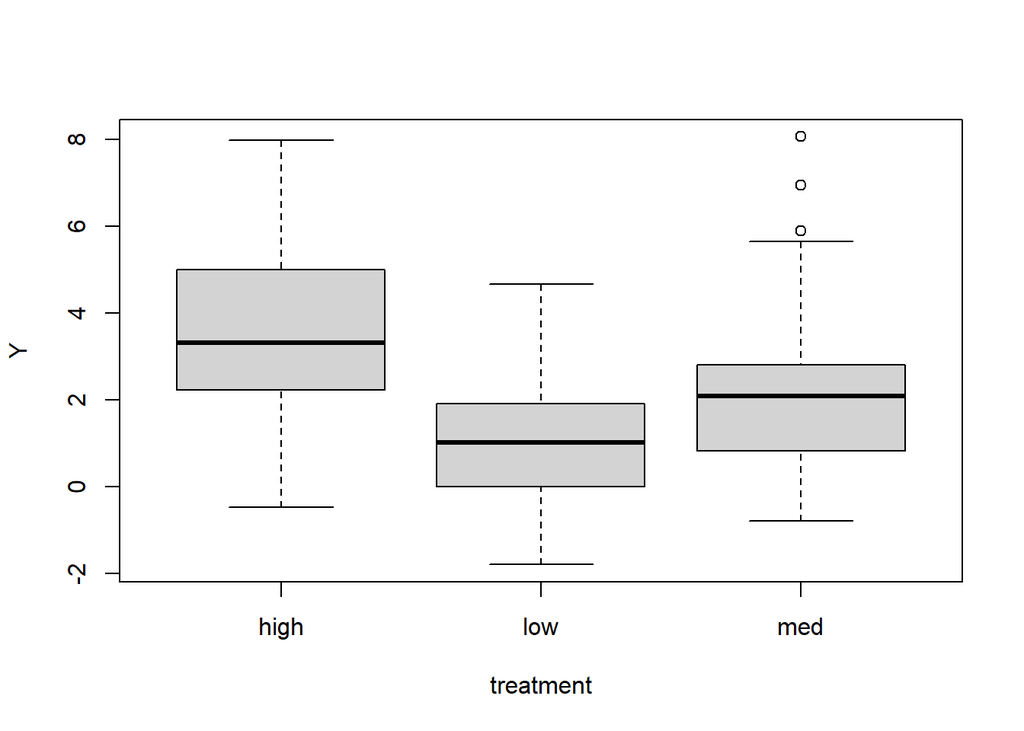

```r
N <- 120
# The effect of treatment
trt.n <- rep(c(-1, 0, 1), N / 3)
mu <- 2 + 1 * trt.n

# Labels for the treatment
treatment <- factor(rep(c("low", "med", "high"), N / 3)) # group labels

# Create, Y, a normally distributed response variable and plot against treatment
Y <- rnorm(N, mu, sd = 2)
boxplot(Y ~ treatment)
```

If we put treatment in as a covariate the normal way, the model will choose a reference treatment (here it will be high as the levels get sorted alphabetically), so that the intercept will be the mean of this reference group. The other coefficients will be the differences between the other groups and the reference group.

```r
cat_lm <- lm(Y ~ treatment)
summary(cat_lm)
```

```
##
## Call:
## lm(formula = Y ~ treatment)
##
## Residuals:
##     Min      1Q  Median      3Q     Max
## -4.0792 -1.3195 -0.1162  0.9930  5.8348
##
## Coefficients:
##              Estimate Std. Error t value Pr(>|t|)
## (Intercept)    3.6149     0.2847  12.698  < 2e-16 ***
## treatmentlow  -2.5263     0.4026  -6.275 6.12e-09 ***
## treatmentmed  -1.3854     0.4026  -3.441 0.000804 ***
## ---
## Signif. codes:  0 '***' 0.001 '**' 0.01 '*' 0.05 '.' 0.1 ' ' 1
##
## Residual standard error: 1.801 on 117 degrees of freedom
## Multiple R-squared:  0.2524, Adjusted R-squared:  0.2396
## F-statistic: 19.75 on 2 and 117 DF,  p-value: 4.08e-08
```

```r
treatment <- relevel(treatment, ref = "low")
cat_lm <- lm(Y ~ treatment)
summary(cat_lm)
```

```
##
## Call:
## lm(formula = Y ~ treatment)
##
## Residuals:
##     Min      1Q  Median      3Q     Max
## -4.0792 -1.3195 -0.1162  0.9930  5.8348
##
## Coefficients:
##               Estimate Std. Error t value Pr(>|t|)
## (Intercept)     1.0886     0.2847   3.824 0.000212 ***
## treatmenthigh   2.5263     0.4026   6.275 6.12e-09 ***
## treatmentmed    1.1409     0.4026   2.834 0.005421 **
## ---
## Signif. codes:  0 '***' 0.001 '**' 0.01 '*' 0.05 '.' 0.1 ' ' 1
##
## Residual standard error: 1.801 on 117 degrees of freedom
## Multiple R-squared:  0.2524, Adjusted R-squared:  0.2396
## F-statistic: 19.75 on 2 and 117 DF,  p-value: 4.08e-08
```

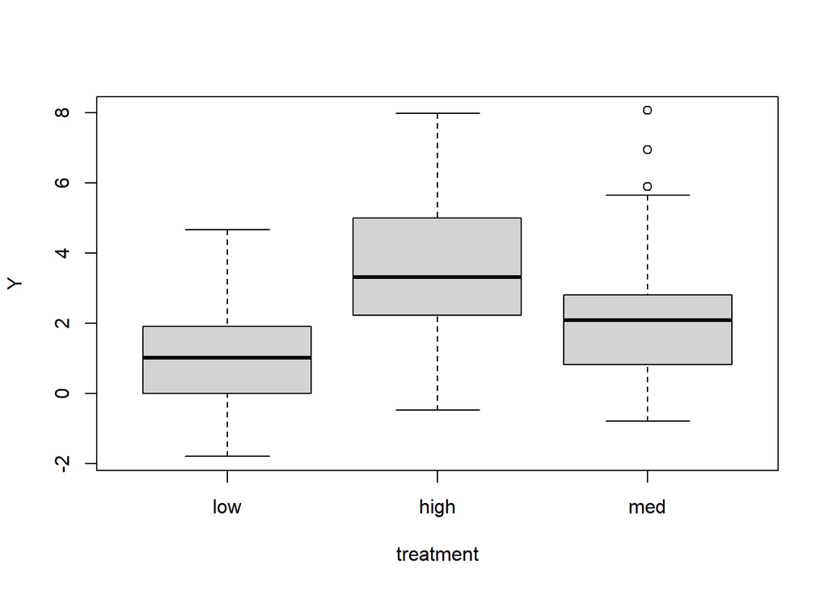

```r
boxplot(Y ~ treatment)
```

Now the intercept is the mean of group “low”, and all the other coefficients are the differences between group “low” and the others. Another thing you can do is to put `-1` in the model to get rid of the intercept, and just have the means of each group as coefficients.

```r
cat_lm <- lm(Y ~ treatment - 1)
summary(cat_lm)
```

```
##
## Call:
## lm(formula = Y ~ treatment - 1)
##
## Residuals:
##     Min      1Q  Median      3Q     Max
## -4.0792 -1.3195 -0.1162  0.9930  5.8348
##
## Coefficients:
##               Estimate Std. Error t value Pr(>|t|)
## treatmentlow    1.0886     0.2847   3.824 0.000212 ***
## treatmenthigh   3.6149     0.2847  12.698  < 2e-16 ***
## treatmentmed    2.2295     0.2847   7.831 2.42e-12 ***
## ---
## Signif. codes:  0 '***' 0.001 '**' 0.01 '*' 0.05 '.' 0.1 ' ' 1
##
## Residual standard error: 1.801 on 117 degrees of freedom
## Multiple R-squared:  0.6697, Adjusted R-squared:  0.6612
## F-statistic: 79.06 on 3 and 117 DF,  p-value: < 2.2e-16
```

Now, the three coefficients are the mean of the groups.

**Contrasting the coefficients** We can also look at contrasts; these are the difference between all pairs of groups. Load the package [multcomp](https://cran.r-project.org/web/packages/multcomp/index.html) and use `glht` (general linear hypotheses) to examine all pair-wise differences.

```r
library(multcomp)

cont <- glht(cat_lm, linfct = mcp(treatment = "Tukey"))

summary(cont)
```

```
##
##   Simultaneous Tests for General Linear Hypotheses
##
## Multiple Comparisons of Means: Tukey Contrasts
##
##
## Fit: lm(formula = Y ~ treatment - 1)
##
## Linear Hypotheses:
##                 Estimate Std. Error t value Pr(>|t|)
## high - low == 0   2.5263     0.4026   6.275  < 1e-04 ***
## med - low == 0    1.1409     0.4026   2.834  0.01485 *
## med - high == 0  -1.3854     0.4026  -3.441  0.00233 **
## ---
## Signif. codes:  0 '***' 0.001 '**' 0.01 '*' 0.05 '.' 0.1 ' ' 1
## (Adjusted p values reported -- single-step method)
```

```r
confint(cont)
```

```
##
##   Simultaneous Confidence Intervals
##
## Multiple Comparisons of Means: Tukey Contrasts
##
##
## Fit: lm(formula = Y ~ treatment - 1)
##
## Quantile = 2.3742
## 95% family-wise confidence level
##
##
## Linear Hypotheses:
##                 Estimate lwr     upr
## high - low == 0  2.5263   1.5704  3.4822
## med - low == 0   1.1409   0.1850  2.0968
## med - high == 0 -1.3854  -2.3413 -0.4295
```

Note: In a model with multiple covariates, the same rules still apply in terms of conditional and marginal interpretations of coefficients.

**Interpreting coefficients in generalised linear models** In linear models, the interpretation of model parameters is linear, as discussed above. For generalised linear models, now read the tutorial page on interpreting coefficients in those models.

**Author**: Gordana Popovic

**Year:** 2016

**Last updated:** Jun. 2023